# Analyzing a Sample of Facebook’s Dataset

[figure not shown]

#### Author: [Abdulaziz Alhaqbani]

# Introduction

This report gives an introductory analysis to explore a sample of 99,003 users from Facebook including variables such as age, gender, tenure, and activities on mobile as well as likes and received likes. The analysis uses the statistical language **R** and its visualization library **ggplot** along with the data manipulation library **dplyr**.

```r
pf <- read.delim('facebook.tsv')
glimpse(pf)
```

```
## Observations: 99,003
## Variables: 15
## $ userid                <int> 2094382, 1192601, 2083884, 1203168, 1733...
## $ age                   <int> 14, 14, 14, 14, 14, 14, 13, 13, 13, 13, ...
## $ dob_day               <int> 19, 2, 16, 25, 4, 1, 14, 4, 1, 2, 22, 1,...
## $ dob_year              <int> 1999, 1999, 1999, 1999, 1999, 1999, 2000...
## $ dob_month             <int> 11, 11, 11, 12, 12, 12, 1, 1, 1, 2, 2, 2...
## $ gender                <fctr> male, female, male, female, male, male,...
## $ tenure                <int> 266, 6, 13, 93, 82, 15, 12, 0, 81, 171, ...
## $ friend_count          <int> 0, 0, 0, 0, 0, 0, 0, 0, 0, 0, 0, 0, 0, 0...
## $ friendships_initiated <int> 0, 0, 0, 0, 0, 0, 0, 0, 0, 0, 0, 0, 0, 0...
## $ likes                 <int> 0, 0, 0, 0, 0, 0, 0, 0, 0, 0, 0, 0, 0, 0...
## $ likes_received        <int> 0, 0, 0, 0, 0, 0, 0, 0, 0, 0, 0, 0, 0, 0...
## $ mobile_likes          <int> 0, 0, 0, 0, 0, 0, 0, 0, 0, 0, 0, 0, 0, 0...
## $ mobile_likes_received <int> 0, 0, 0, 0, 0, 0, 0, 0, 0, 0, 0, 0, 0, 0...
## $ www_likes             <int> 0, 0, 0, 0, 0, 0, 0, 0, 0, 0, 0, 0, 0, 0...
## $ www_likes_received    <int> 0, 0, 0, 0, 0, 0, 0, 0, 0, 0, 0, 0, 0, 0...
```

Displaying a sample of selected rows 50000 to 500010:

```r
pf[50000:50010, c("userid", "age","gender", "tenure",'friend_count','likes','friendships_initiated')]
```

```
##        userid age gender tenure friend_count likes friendships_initiated
## 50000 1748320  53   male    440           82    52                    32
## 50001 1945632  25 female    211           83    53                    75
## 50002 1586049  24 female    405           83    53                    78
## 50003 1788777 100   male   1848           83    53                    32
## 50004 1854306  48   male    325           84    53                    57
## 50005 2151336 103 female   2141           82    53                    43
## 50006 1193138  29 female    374           84    52                    45
## 50007 1738817  59 female    383           82    54                    25
## 50008 1729016  26 female    504           83    55                    63
## 50009 1624556  33 female    602           84    55                    66
## 50010 1710693  33 female     59           83    54                    38
```

With using the library **psych**, we can get more in-depth statistics such as *standard deviation*,*mad* (mean absolute deviation) and *skew* (measures if the data distribution is symmetrical):

```r
describe (pf %>% select(age,likes,friendships_initiated))
```

```
##                       vars     n   mean     sd median trimmed   mad min
## age                      1 99003  37.28  22.59     28   33.60 14.83  13
## likes                    2 99003 156.08 572.28     11   45.18 16.31   0
## friendships_initiated    3 99003 107.45 188.79     46   66.97 53.37   0
##                         max range  skew kurtosis   se
## age                     113   100  1.42     1.56 0.07
## likes                 25111 25111 11.02   200.43 1.82
## friendships_initiated  4144  4144  5.15    42.53 0.60
```

## Exploring the Variable: *Day of Birthdate*

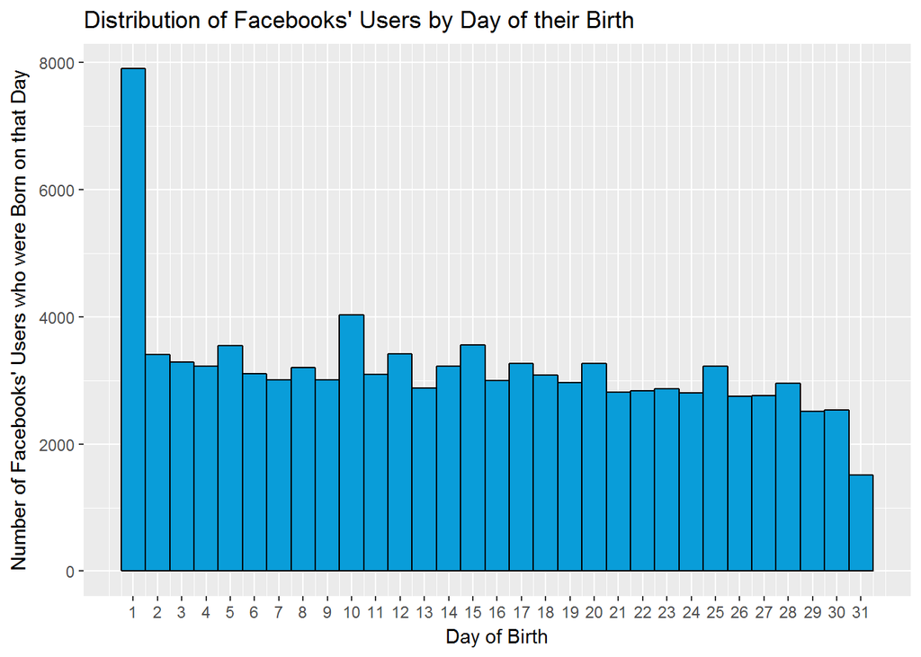

```r
ggplot(aes(x = dob_day), data = pf) +
  geom_histogram(binwidth = 1,color = 'black', fill = '#099DD9') +
  scale_x_continuous(breaks = 1:31) +
   xlab('Day of Birth') +
  ylab("Number of Facebooks' Users who were Born on that Day")+
  ggtitle("Distribution of Facebooks' Users by Day of their Birth")
```

At first glance, we notice about this histogram that the 1st day of the month is considerably & unreasonably higher than other days. Definitely needs further investigation.

Let us visualize all other months (January to December) and see if the above pattern could differ.

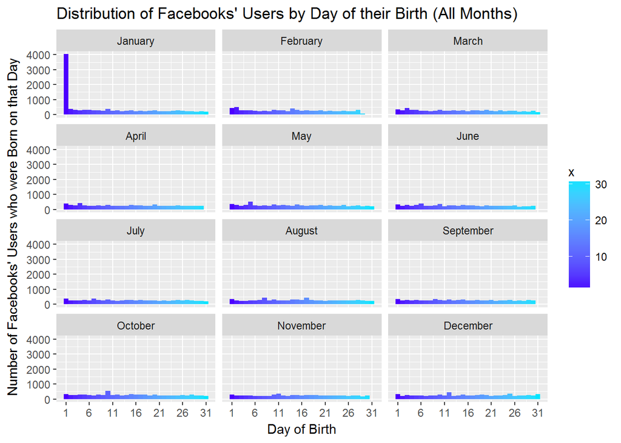

```r
Months_name <- c(   "1" = "January",
                    "2" = "February",
                    "3" = "March",
                    "4" = "April",
                    "5" = "May",
                    "6" = "June",
                    "7" = "July",
                    "8" = "August",
                    "9" = "September",
                    "10" = "October",
                    "11" = "November",
                    "12" = "December"
                    )

ggplot(aes(x = dob_day), data = pf) +
  geom_histogram(binwidth = 1,aes(fill = ..x..)) +
  scale_x_continuous(breaks = seq(1, 31, 5)) +
  facet_wrap(~dob_month,ncol=3,labeller = as_labeller(Months_name)) +
  scale_fill_gradientn(colours = topo.colors(2)) +
  xlab('Day of Birth') +
  ylab("Number of Facebooks' Users who were Born on that Day")+
  ggtitle("Distribution of Facebooks' Users by Day of their Birth (All Months)")
```

Apparently, the Facebook’s default birthdate is January 1st, and a large set of users may refuse/ or even slack off to show their real birthdate.

## Exploring the variable: *Friend Count*

The variable *Friend Count* sums all the friends for a selected user regardless who initiated the friendship first. We expect this variable to be right-skewed with major outliers that could affect the mean.

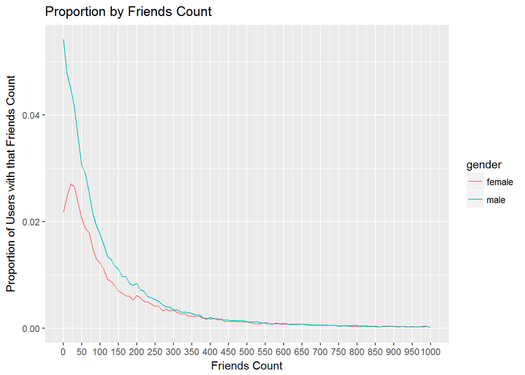

```r
ggplot(aes(x = friend_count, y = ..count../sum(..count..)),
       data = subset(pf, !is.na(gender))) +
  geom_freqpoly(aes(color = gender), binwidth=10) +
  scale_x_continuous(limits = c(0, 1000), breaks = seq(0, 1000, 50)) +
  xlab('Friends Count') +
  ylab('Proportion of Users with that Friends Count')+
  ggtitle("Proportion by Friends Count")
```

As expected, the data is packed tightly under 1000 friends count, and notable outliers above 3000 and even 4000.

### Logarithmic and Square Root Transformations

Another view of visualization can be obtained if we scale the x-axis on log10 and square root in order to respond to the variable’s skewness towards large values:

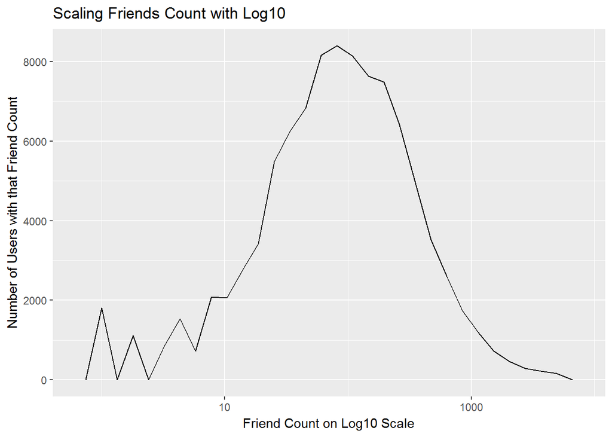

```r
ggplot(aes(x = friend_count), data = pf) +
  geom_freqpoly(color = 'black')  +
  ylab('Number of Users with that Friend Count') +
  xlab('Friend Count on Log10 Scale') +  scale_x_log10() +
  ggtitle("Scaling Friends Count with Log10")
```

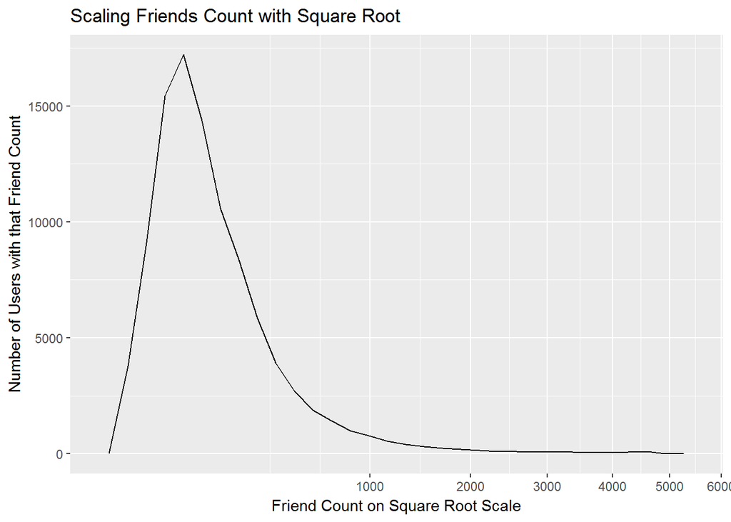

```r
ggplot(aes(x = friend_count), data = pf) +
  geom_freqpoly(color = 'black')  +
  ylab('Number of Users with that Friend Count') +
  scale_x_sqrt() + xlab('Friend Count on Square Root Scale') +
  ggtitle("Scaling Friends Count with Square Root")
```

Limiting the x-axis to only include less than 1000 friends count by using the ggplot2’s continuous scale **scale_x_continuous** and adjust the binwidth to 25. We also will add a **facet_wrap** to show genders.

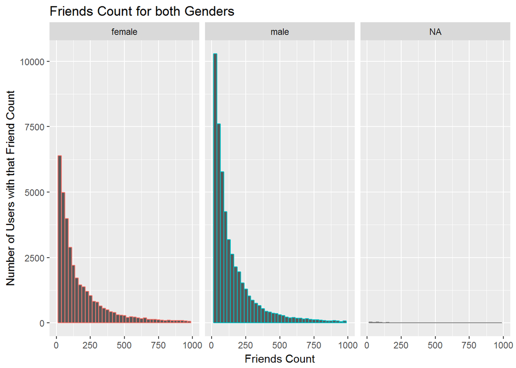

```r
ggplot(aes(x = friend_count,color=gender), data = pf) +
  geom_histogram(binwidth = 25,aes(color = gender)) +
  scale_x_continuous(limits = c(0, 1000), breaks = seq(0, 1000, 250)) +
  facet_wrap(~gender) + guides(color = "none") +
  ylab('Number of Users with that Friend Count') +
  xlab('Friends Count') +
  ggtitle("Friends Count for both Genders")
```

It seems that some users opted to hide their sexuality, we need to omit those NA values by using **!is.na(gender)** on the Facebook’s dataset.

Additionally, we cannot easily decide if males on average have higher friends on Facebooks than females from the above visualization, therefore we need to make use of boxplot as well as display some descriptive statistics to clear out the ambiguity:

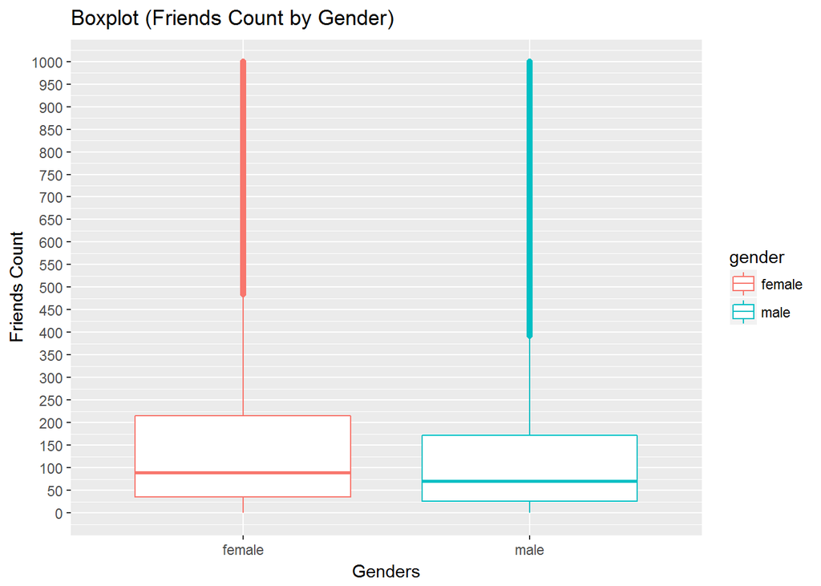

```r
ggplot(data = subset(pf, !is.na(gender)), aes(gender, friend_count)) +
  geom_boxplot(aes(color = gender))+
  scale_y_continuous(limits = c(0, 1000), breaks = seq(0, 1000, 50)) +
  xlab('Genders') +
  ylab('Friends Count') +
  ggtitle("Boxplot (Friends Count by Gender)")
```

```r
table(pf$gender)
```

```
##
## female   male
##  40254  58574
```

```r
by(pf$friend_count,pf$gender,summary)
```

```
## pf$gender: female
##    Min. 1st Qu.  Median    Mean 3rd Qu.    Max.
##       0      37      96     242     244    4923
## --------------------------------------------------------
## pf$gender: male
##    Min. 1st Qu.  Median    Mean 3rd Qu.    Max.
##       0      27      74     165     182    4917
```

Females have higher both median & mean than males. But notable to say, the median is a suitable measurement here since the mean’s difference in both gender is quite varied, and such variance could have been caused by extreme outliers.

## Exploring the Variable: *Tenure*

The variable *Tenure* indicates how many days the Facebook’s user have been passed since he/she registered in. Note that the Facebook as a social media website was launched back in 2004, it would make sense if the histogram is going to be right-skewed due to the fact the social media booming started after 2008.

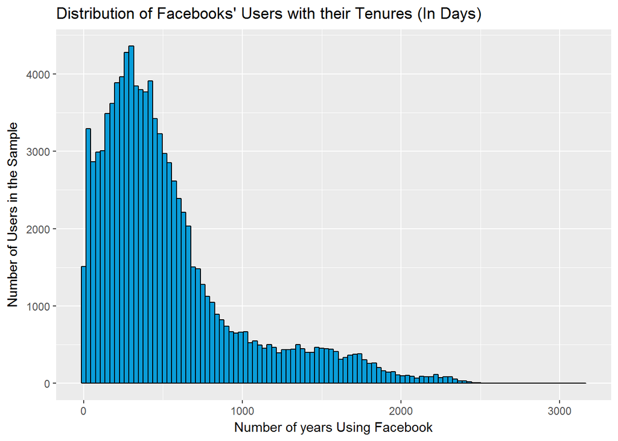

```r
ggplot(aes(x = tenure), data = pf) +
  geom_histogram(binwidth = 30, color = 'black', fill = '#099DD9') +
    xlab('Number of years Using Facebook') +
    ylab('Number of Users in the Sample') +
    ggtitle("Distribution of Facebooks' Users with their Tenures (In Days)")
```

Let us scale the units of *tenure* from days to years to enhance readability by dividing the variable by 360.

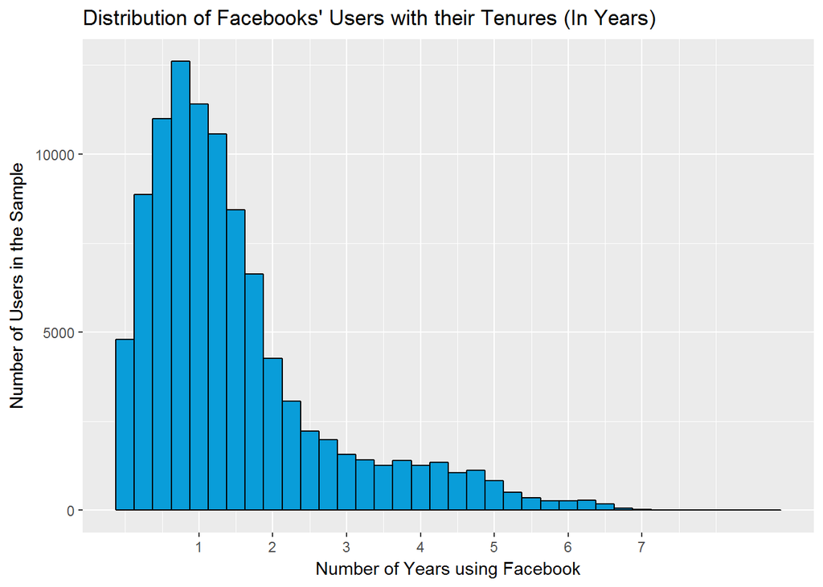

```r
qplot(x = tenure/360,  data = pf ,binwidth = .25,
      xlab = 'Number of Years using Facebook',
      ylab = 'Number of Users in the Sample',
  color = I('black'), fill = I('#099DD9'))+
  scale_x_continuous(breaks= seq(1,7,1))+
  ggtitle("Distribution of Facebooks' Users with their Tenures (In Years)")
```

There could be something interesting if we limit the x-axis boundaries to from 7 years to 9 years:

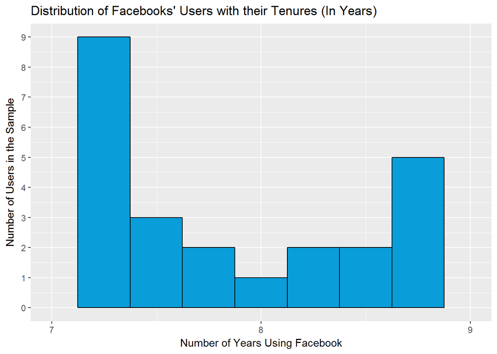

```r
qplot(x = tenure/360,  data = pf ,binwidth = .25,
      xlab = 'Number of Years Using Facebook',
      ylab = 'Number of Users in the Sample',
  color = I('black'), fill = I('#099DD9'))+
  scale_x_continuous(breaks= seq(7,9,1), limits = c(7,9)) +
  scale_y_continuous(breaks= seq(0,10,1)) +
    ggtitle("Distribution of Facebooks' Users with their Tenures (In Years)")
```

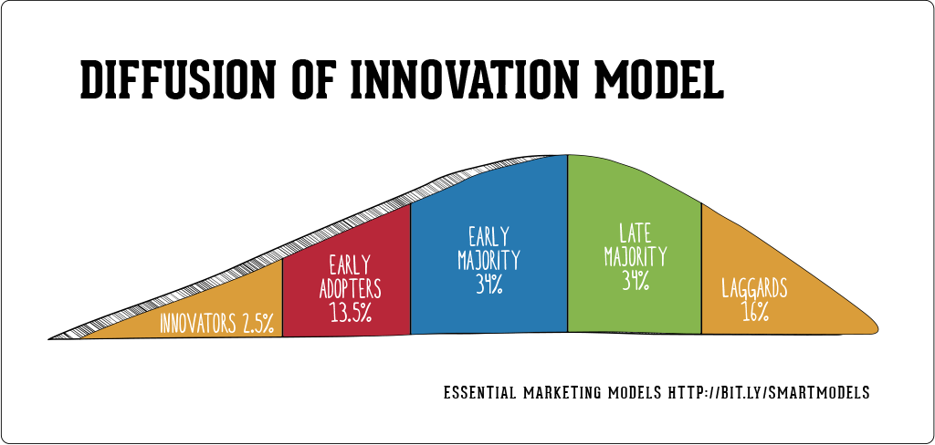

# Multivariate Analysis

Facebook’s policies do not allow kids under 13 to sign up and use the service, we assume the dataset will comply with such rule. Now we are curious to see if there is a correlation between age and friends count.

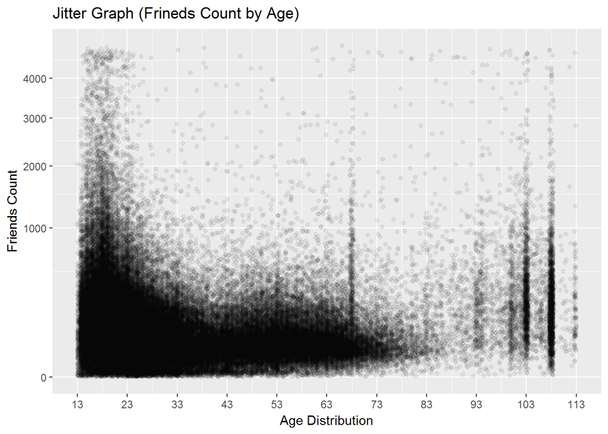

```r
ggplot(aes(x = age, y = friend_count), data = pf) +
  geom_point(alpha = 1/15,position = 'jitter') +
  coord_trans(y = "sqrt")+ylim(0,max(pf$friend_count)) +
  xlab('Age Distribution') +
  ylab('Friends Count') +
  ggtitle("Jitter Graph (Frineds Count by Age)") +
  scale_x_continuous(limits = c(13, 113), breaks = seq(13, 113, 10))
```

There are unusual spikes beyond the age of 100 as well as around 69 and 68. One reason could be the retirement age for some countries of the world is 70 where retirees could finally have free time to deep dive in the social media era or make virtual reunions with their peers. On the other side, those users exceeding the age of 100 probably they are actually playing around with fakes accounts.

### Smoothing with Linear Model

In Facebook’s realm, users can express their appreciation for a post or event by giving a thump-up which means *Like*. One could wonder if users tend to give more likes through their mobiles more than the standard computer (laptop, desktop) ? The graph below may give us a hint.

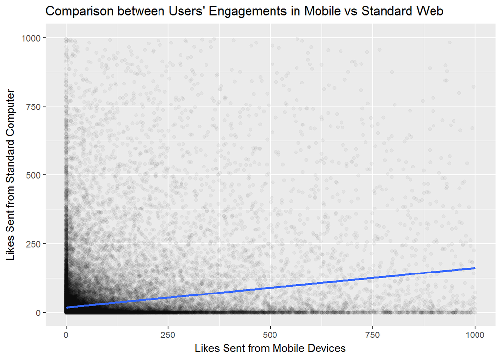

```r
ggplot(aes(x = mobile_likes, y = www_likes), data = pf) +
  geom_jitter(alpha= 1/25) + xlim(0,1000)+ylim(0,1000)+geom_smooth(method = lm) +
  xlab('Likes Sent from Mobile Devices') +
  ylab('Likes Sent from Standard Computer') +
  ggtitle("Comparison between Users' Engagements in Mobile vs Standard Web ")
```

Mobiles (or smartphones as they say) seem to have overtaken the standard browsers in terms of users’ engagements and overall activity. This simply could be related to the availability of speed internet connection as well as the relatively low prices of smartphones. And lastly, the user experience has been much improved generally in the apps industry where all ages can conveniently use them without much of a struggle.

[figure not shown]

### Pearson Correlation Coefficient

Is there a correlation between having many virtual friends and receiving *likes*? The Pearson Correlation Coefficient is a measurement to identify such a correlation as shown below.

```r
cor.test(pf$friend_count,pf$likes_received)
```

```
##
##  Pearson's product-moment correlation
##
## data:  pf$friend_count and pf$likes_received
## t = 76.573, df = 99001, p-value < 2.2e-16
## alternative hypothesis: true correlation is not equal to 0
## 95 percent confidence interval:
##  0.2305736 0.2423352
## sample estimates:
##       cor
## 0.2364631
```

0.23 isn’t that solid indicator, yet a slight positive correlation we can assume.

# Conclusion

We explored a several set of Facebook’s dateset variables, along with multiple visualizations that shed the lights on hidden insights. Human behavior and the psychology behind using social media can be revealed further from such datasets since most of us typically spend long hours a day surfing them. In fact, the social media networks undeniably have become quite a part of our lives. At the end, tt is where the role of data analysis comes to play; extracting meaningful knowledge from seemingly raw data.